# DEA_ssudalag

# Hope Valley Health Care Association Data Envelopment Analysis(DEA)

### Inputs = Staff Hours per day, Supplies per day

### Outputs = Reimbursed Patient-Days, Privately paid patient days

```r
library("Benchmarking")
x <- matrix(c(150,400,320,520,350,320,0.2,0.7,1.2,2.0,1.2,0.7),ncol = 2)
y <- matrix(c(14000,14000,42000,28000,19000,14000,3500,21000,10500,42000,25000,15000),ncol = 2)
x
```

```
##      [,1] [,2]
## [1,]  150  0.2
## [2,]  400  0.7
## [3,]  320  1.2
## [4,]  520  2.0
## [5,]  350  1.2
## [6,]  320  0.7
```

```r
y
```

```
##       [,1]  [,2]
## [1,] 14000  3500
## [2,] 14000 21000
## [3,] 42000 10500
## [4,] 28000 42000
## [5,] 19000 25000
## [6,] 14000 15000
```

```r
colnames(x) <- c("Staff hours per day","Supplies per day")
colnames(y) <- c("Reimbursed patient-days","Privately paid patient days")
x
```

```
##      Staff hours per day Supplies per day
## [1,]                 150              0.2
## [2,]                 400              0.7
## [3,]                 320              1.2
## [4,]                 520              2.0
## [5,]                 350              1.2
## [6,]                 320              0.7
```

```r
y
```

```
##      Reimbursed patient-days Privately paid patient days
## [1,]                   14000                        3500
## [2,]                   14000                       21000
## [3,]                   42000                       10500
## [4,]                   28000                       42000
## [5,]                   19000                       25000
## [6,]                   14000                       15000
```

## DEA with RTS = FDH

```r
d <- dea(x,y,RTS = "FDH")
d
```

```
## [1] 1 1 1 1 1 1
```

### peers

```r
peers(d)
```

```
##      peer1
## [1,]     1
## [2,]     2
## [3,]     3
## [4,]     4
## [5,]     5
## [6,]     6
```

### lambdas

```r
lambda(d)
```

```
##      L1 L2 L3 L4 L5 L6
## [1,]  1  0  0  0  0  0
## [2,]  0  1  0  0  0  0
## [3,]  0  0  1  0  0  0
## [4,]  0  0  0  1  0  0
## [5,]  0  0  0  0  1  0
## [6,]  0  0  0  0  0  1
```

### plot

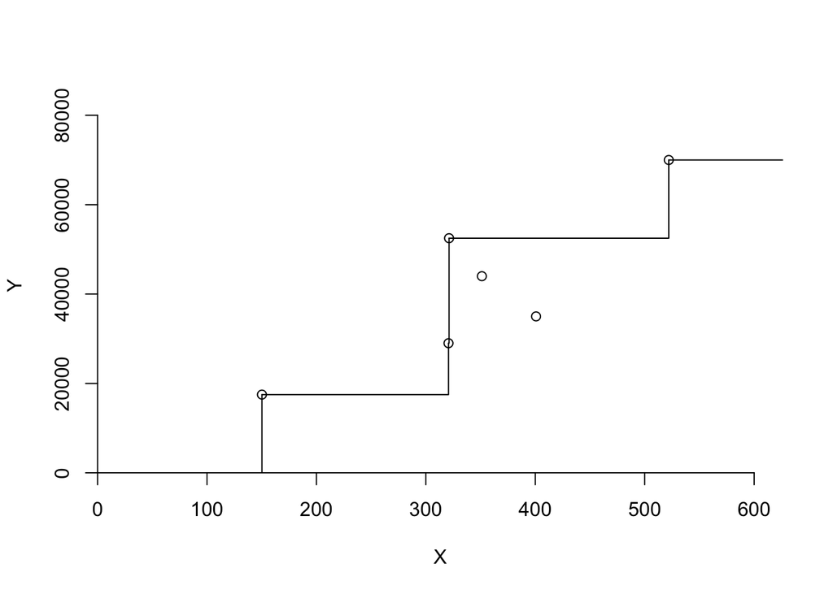

```r
dea.plot.frontier(x,y,RTS = "FDH")
```

### The results for the Data envelopment analysis using the FDH shows that there are no ineffecient facilities

## DEA with RTS = CRS

```r
d <- dea(x,y,RTS = "CRS")
d
```

```
## [1] 1.0000 1.0000 1.0000 1.0000 0.9775 0.8675
```

### peers

```r
peers(d)
```

```
##      peer1 peer2 peer3
## [1,]     1    NA    NA
## [2,]     2    NA    NA
## [3,]     3    NA    NA
## [4,]     4    NA    NA
## [5,]     1     2     4
## [6,]     1     2     4
```

### lambdas

```r
lambda(d)
```

```
##             L1         L2 L3        L4
## [1,] 1.0000000 0.00000000  0 0.0000000
## [2,] 0.0000000 1.00000000  0 0.0000000
## [3,] 0.0000000 0.00000000  1 0.0000000
## [4,] 0.0000000 0.00000000  0 1.0000000
## [5,] 0.2000000 0.08048142  0 0.5383307
## [6,] 0.3428571 0.39499264  0 0.1310751
```

### plot

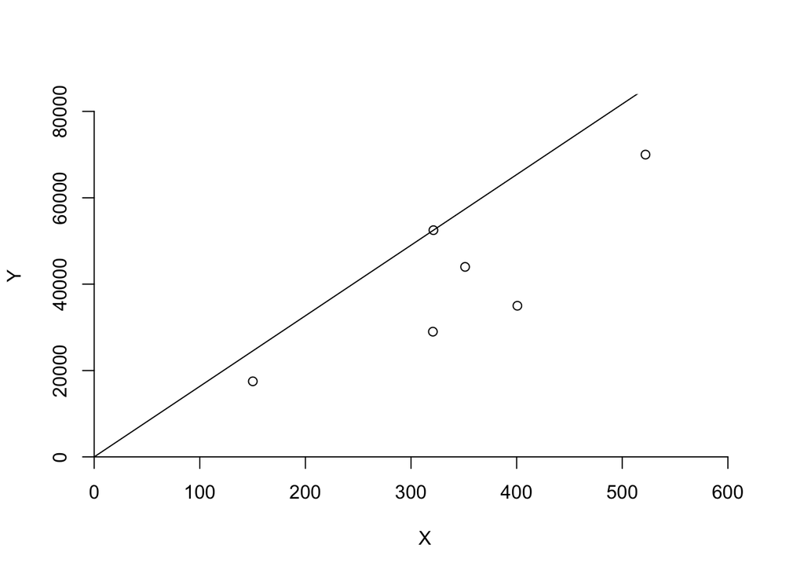

```r
dea.plot.frontier(x,y,RTS = "CRS")
```

### The results for the Data envelopment analysis using the CRS shows that facility 5 and facility 6 are ineffecient facilities and their peers are facility 1,2,4 and lambda shows the weightage on each of the facilities

## DEA with RTS = VRS

```r
d <- dea(x,y,RTS = "VRS")
d
```

```
## [1] 1.0000 1.0000 1.0000 1.0000 1.0000 0.8963
```

### peers

```r
peers(d)
```

```
##      peer1 peer2 peer3
## [1,]     1    NA    NA
## [2,]     2    NA    NA
## [3,]     3    NA    NA
## [4,]     4    NA    NA
## [5,]     5    NA    NA
## [6,]     1     2     5
```

### lambdas

```r
lambda(d)
```

```
##             L1        L2 L3 L4        L5
## [1,] 1.0000000 0.0000000  0  0 0.0000000
## [2,] 0.0000000 1.0000000  0  0 0.0000000
## [3,] 0.0000000 0.0000000  1  0 0.0000000
## [4,] 0.0000000 0.0000000  0  1 0.0000000
## [5,] 0.0000000 0.0000000  0  0 1.0000000
## [6,] 0.4014399 0.3422606  0  0 0.2562995
```

### plot

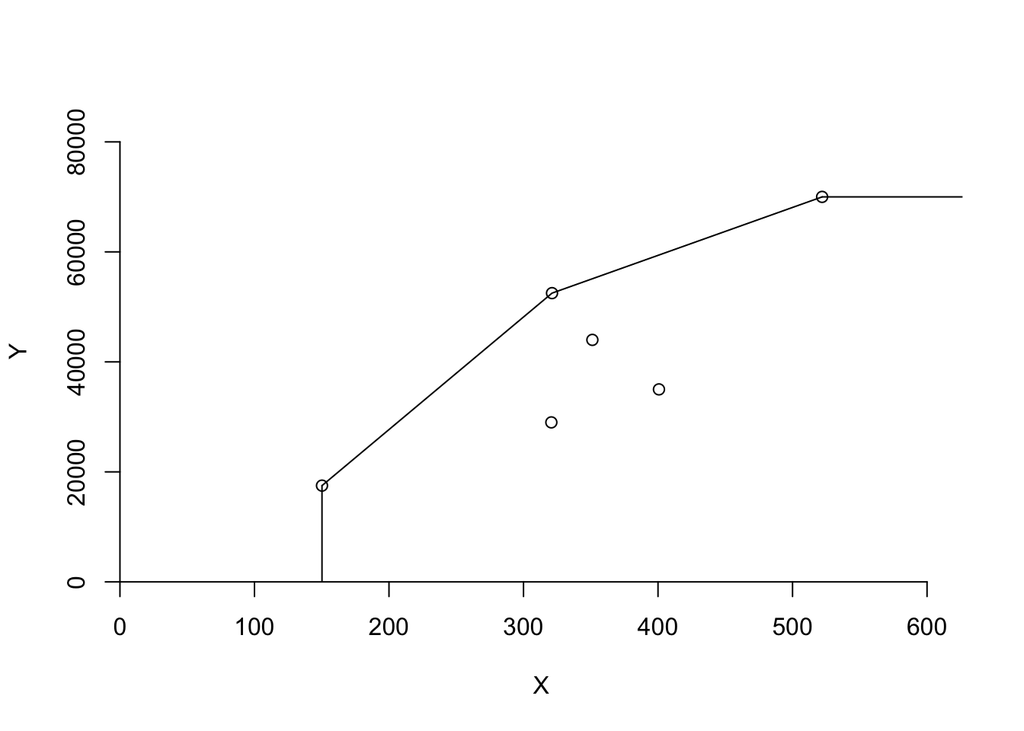

```r
dea.plot.frontier(x,y,RTS = "VRS")
```

### The results for the Data envelopment analysis using the VRS shows that facility 6 is ineffecient facility and the peers are facility 1,2,5 and lambda shows the weightage on each of the facilities

## DEA with RTS = IRS

```r
d <- dea(x,y,RTS = "IRS")
d
```

```
## [1] 1.0000 1.0000 1.0000 1.0000 1.0000 0.8963
```

### peers

```r
peers(d)
```

```
##      peer1 peer2 peer3
## [1,]     1    NA    NA
## [2,]     2    NA    NA
## [3,]     3    NA    NA
## [4,]     4    NA    NA
## [5,]     5    NA    NA
## [6,]     1     2     5
```

### lambdas

```r
lambda(d)
```

```
##             L1        L2 L3 L4        L5
## [1,] 1.0000000 0.0000000  0  0 0.0000000
## [2,] 0.0000000 1.0000000  0  0 0.0000000
## [3,] 0.0000000 0.0000000  1  0 0.0000000
## [4,] 0.0000000 0.0000000  0  1 0.0000000
## [5,] 0.0000000 0.0000000  0  0 1.0000000
## [6,] 0.4014399 0.3422606  0  0 0.2562995
```

### plot

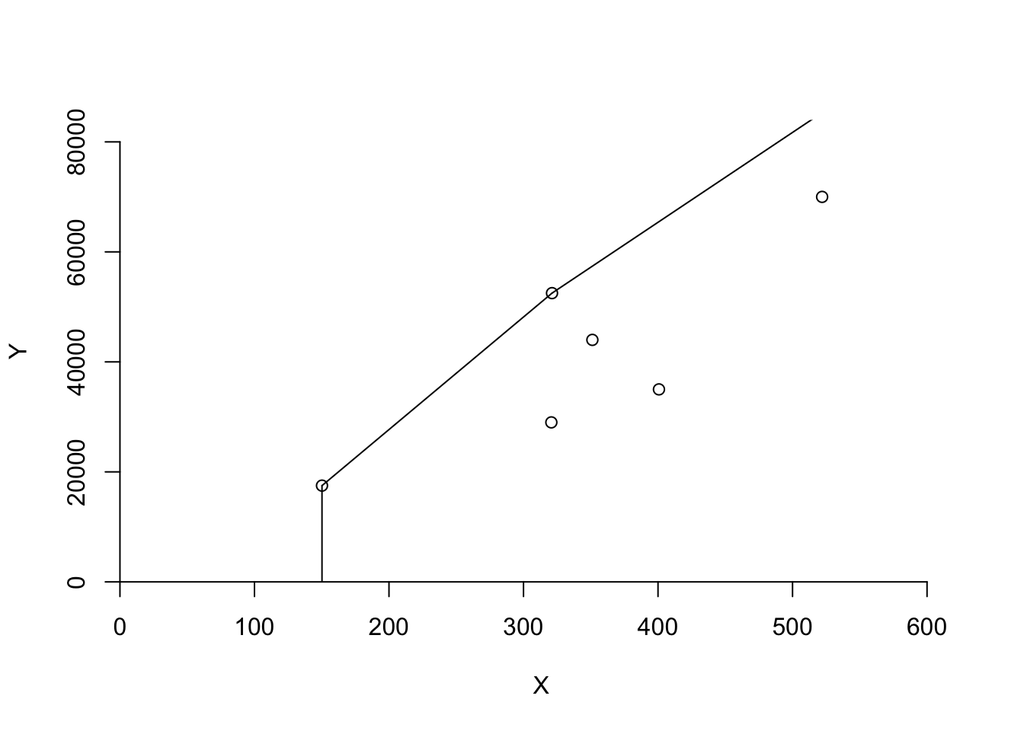

```r
dea.plot.frontier(x,y,RTS="IRS")
```

### The results for the Data envelopment analysis using the IRS shows that facility 6 is ineffecient facility and the peers are facility 1,2,5 and lambda shows the weightage on each of the facilities

## DEA with RTS = DRS

```r
d <- dea(x,y,RTS = "DRS")
d
```

```
## [1] 1.0000 1.0000 1.0000 1.0000 0.9775 0.8675
```

### peers

```r
peers(d)
```

```
##      peer1 peer2 peer3
## [1,]     1    NA    NA
## [2,]     2    NA    NA
## [3,]     3    NA    NA
## [4,]     4    NA    NA
## [5,]     1     2     4
## [6,]     1     2     4
```

### lambdas

```r
lambda(d)
```

```
##             L1         L2 L3        L4
## [1,] 1.0000000 0.00000000  0 0.0000000
## [2,] 0.0000000 1.00000000  0 0.0000000
## [3,] 0.0000000 0.00000000  1 0.0000000
## [4,] 0.0000000 0.00000000  0 1.0000000
## [5,] 0.2000000 0.08048142  0 0.5383307
## [6,] 0.3428571 0.39499264  0 0.1310751
```

### plot

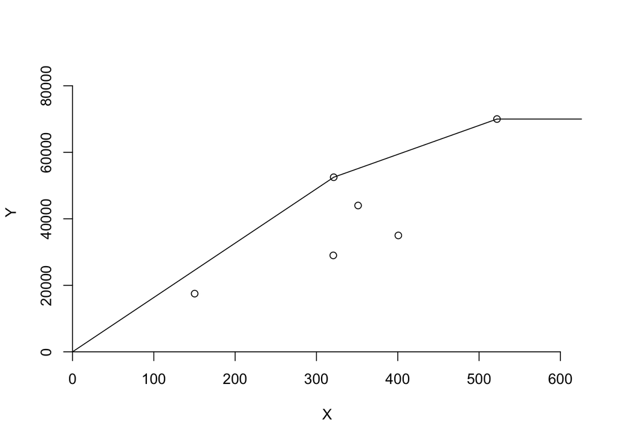

```r
dea.plot.frontier(x,y,RTS = "DRS")
```

### The results for the Data envelopment analysis using the DRS shows that facility 5 and facility 6 are ineffecient facilities and their peers are facility 1,2,4 and lambda shows the weightage on each of the facilities

## DEA with RTS = FRH

```r
d <- dea(x,y,RTS = "fdh+")
d
```

```
## [1] 1 1 1 1 1 1
```

### peers

```r
peers(d)
```

```
##      peer1
## [1,]     1
## [2,]     2
## [3,]     3
## [4,]     4
## [5,]     5
## [6,]     6
```

### lambdas

```r
lambda(d)
```

```
##      L1 L2 L3 L4 L5 L6
## [1,]  1  0  0  0  0  0
## [2,]  0  1  0  0  0  0
## [3,]  0  0  1  0  0  0
## [4,]  0  0  0  1  0  0
## [5,]  0  0  0  0  1  0
## [6,]  0  0  0  0  0  1
```

### plot

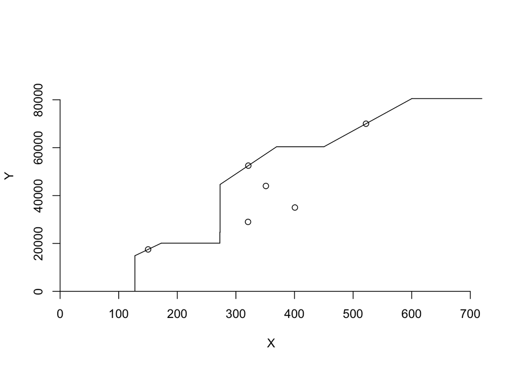

```r
dea.plot.frontier(x,y,RTS = "fdh+")
```

### The results for the Data envelopment analysis using the FRH shows that there are no ineffecient facilities

## Sumarising the results in tabular format. Inefficient = inefficient facilities

## P1,P2,P3 = Peers

## L1,L2,L3,L4,L5,L6 = Lambda

```r
i <- matrix(c(0,5,6,6,6,5,6,0,NA,1,1,1,1,1,1,NA,NA,2,2,2,2,2,2,NA,NA,4,4,5,5,4,4,NA,0,0.20,0.34,0.40,0.40,0.20,0.34,0,0,0.08,0.39,0.34,0.34,0.08,0.39,0,0,0,0,0,0,0,0,0,0,0.53,0.13,0,0,0.53,0.13,0,0,0,0,0.25,0.25,0,0,0,0,0,0,0,0,0,0,0),ncol = 10)
rownames(i) <- (c("FDH","CRS","CRS","VRS","IRS","DRS","DRS","FRH"))
colnames(i) <- c("Inefficient","P1","P2","P3","L1","L2","L3","L4","L5","L6")
result <- as.table(i)
library(knitr)
kable(result,caption = "DEA")
```

DEA

|  | Inefficient | P1 | P2 | P3 | L1 | L2 | L3 | L4 | L5 | L6 |
| --- | --- | --- | --- | --- | --- | --- | --- | --- | --- | --- |
| FDH | 0 | NA | NA | NA | 0.00 | 0.00 | 0 | 0.00 | 0.00 | 0 |
| CRS | 5 | 1 | 2 | 4 | 0.20 | 0.08 | 0 | 0.53 | 0.00 | 0 |
| CRS | 6 | 1 | 2 | 4 | 0.34 | 0.39 | 0 | 0.13 | 0.00 | 0 |
| VRS | 6 | 1 | 2 | 5 | 0.40 | 0.34 | 0 | 0.00 | 0.25 | 0 |
| IRS | 6 | 1 | 2 | 5 | 0.40 | 0.34 | 0 | 0.00 | 0.25 | 0 |
| DRS | 5 | 1 | 2 | 4 | 0.20 | 0.08 | 0 | 0.53 | 0.00 | 0 |
| DRS | 6 | 1 | 2 | 4 | 0.34 | 0.39 | 0 | 0.13 | 0.00 | 0 |
| FRH | 0 | NA | NA | NA | 0.00 | 0.00 | 0 | 0.00 | 0.00 | 0 |